# BraKetVue: Vue.js + TypeScript for quantum state visualization

Piotr Migdal, Klem Jankiewicz

11 Aug 2020, NYC Quantum Computing Meetup

# Intro

## We

Talk: http://p.migdal.pl/nyc-qc-braketvue/#/

- **Piotr Migdal**
  - quantum optics theory PhD from ICFO (2014)
  - advisor: Maciej Lewenstein
  - data vis & deep learning consultant (2015-2020)
  - [Quantum mechanics for high-school students](https://p.migdal.pl/2016/08/15/quantum-mechanics-for-high-school-students.html)
- **Klem Jankiewicz**
  - designer, UX/UI
  - intersection of technology, education and design
  - (now also: JS, git, and QM)

We have just founded Quantum Flytrap.

## Quantum Game with Photons

We worked in Centre for Quantum Technologies in Singapore, invited by **Artur Ekert**:

> All I want is the coolest quantum game in the known multiverse, please!

Our goal is to become a game-changer for e-learning: an essential tool for educators in the field of **quantum cryptography** and **quantum computing**.

## Quantum Flytrap

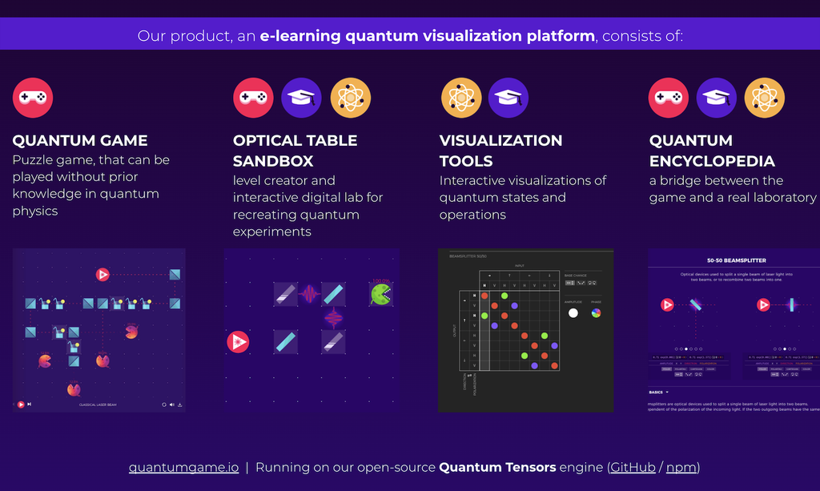

quantumgame.io

## Visualization tools

You can play the game in your free time. :)

Now, let’s focus on visualization and go beyond static LaTeX:

$$| \psi \rangle = \frac{| 0 \rangle + | 1 \rangle}{\sqrt{2}}$$

# BraKetVue

## BraKetVue

⟨𝜑|𝜓⟩.vue - a Vue-based visualization of quantum states and operations

- extracted from Quantum Game
- mastered as a stand-alone tool
- in TypeScript (vide my love story [How I Learned to Stop Worrying and Love the Types & Tests](https://p.migdal.pl/2020/03/02/types-tests-typescript.html))
- supported by the [Unitary Fund](https://unitary.fund/) (Apr-May 2020)
- for YOU to use in your interactive materials!

## Core ideas

- discrete state
- beyond qubits
- named dimensions
- multiple representations
  - complex numbers: polar, cartesian or…?
  - dynamic change of basis
- for any system (also user-defined)
- embeddable in blog posts

# Operators

## Hadamard

## CNOT

The simplest two-qubit gate

## Toffoli

Quantum AND

## Spin-Z

One of the Pauli matrices

```
const spinZ = Operator.fromSparseCoordNames([
  ['u', 'u', Cx(1)],
  ['d', 'd', Cx(-1)],
], [Dimension.spin()]);
```

## A 50:50 non-polarizing beam-splitter

## In dark mode

## Truth table

# Call to action

## How to use it

In deep learning it is a good standard to set up a `github.io` page with demo.

- [Distill for R Markdown](https://rstudio.github.io/distill/):
  - see https://p.migdal.pl/bra-ket-vue-art/
- [JSFiddle](https://jsfiddle.net/):
  - [examples](https://jsfiddle.net/user/stared/fiddles/), within a Jupyter presentation
- Created using [R Markdown Reveal.js](https://github.com/rstudio/revealjs): [these slides](https://github.com/stared/nyc-qc-braketvue)!
- Directly in Vue.js, e.g. [Quantum Game](https://quantumgame.io/) in general: [MZ interferometer](https://quantumgame.io/info/mach-zehnder-interferometer), [Faraday rotator](https://quantumgame.io/info/faraday-rotator)

## Thanks!

github.com/Quantum-Game/bra-ket-vue

Contact: `pmigdal@gmail.com`, Twitter: pmigdal

Especially if you want to use it in your project, academic or commercial.